# Optimal Treatment Analysis

## Outcome Variable

**Outcome Variable:** ever_stunted

## Predictor Variables

**Intervention Variable:** single

**Adjustment Set:**

- arm
- W_mage
- meducyrs
- feducyrs
- W_mhtcm
- W_mwtkg
- W_mbmi
- delta_W_mage
- delta_meducyrs
- delta_feducyrs
- delta_W_mhtcm
- delta_W_mwtkg
- delta_W_mbmi

## Stratifying Variables

The analysis was stratified on these variable(s):

- agecat
- studyid
- country

## Data Summary

| agecat | studyid | country | single | ever_stunted | n_cell | n |
| --- | --- | --- | --- | --- | --- | --- |
| 0-24 months | ki0047075b-MAL-ED | BANGLADESH | 0 | 0 | 104 | 265 |
| 0-24 months | ki0047075b-MAL-ED | BANGLADESH | 0 | 1 | 161 | 265 |
| 0-24 months | ki0047075b-MAL-ED | BANGLADESH | 1 | 0 | 0 | 265 |
| 0-24 months | ki0047075b-MAL-ED | BANGLADESH | 1 | 1 | 0 | 265 |
| 0-24 months | ki0047075b-MAL-ED | BRAZIL | 0 | 0 | 154 | 233 |
| 0-24 months | ki0047075b-MAL-ED | BRAZIL | 0 | 1 | 43 | 233 |
| 0-24 months | ki0047075b-MAL-ED | BRAZIL | 1 | 0 | 25 | 233 |
| 0-24 months | ki0047075b-MAL-ED | BRAZIL | 1 | 1 | 11 | 233 |
| 0-24 months | ki0047075b-MAL-ED | INDIA | 0 | 0 | 101 | 249 |
| 0-24 months | ki0047075b-MAL-ED | INDIA | 0 | 1 | 148 | 249 |
| 0-24 months | ki0047075b-MAL-ED | INDIA | 1 | 0 | 0 | 249 |
| 0-24 months | ki0047075b-MAL-ED | INDIA | 1 | 1 | 0 | 249 |
| 0-24 months | ki0047075b-MAL-ED | NEPAL | 0 | 0 | 157 | 240 |
| 0-24 months | ki0047075b-MAL-ED | NEPAL | 0 | 1 | 83 | 240 |
| 0-24 months | ki0047075b-MAL-ED | NEPAL | 1 | 0 | 0 | 240 |
| 0-24 months | ki0047075b-MAL-ED | NEPAL | 1 | 1 | 0 | 240 |
| 0-24 months | ki0047075b-MAL-ED | PERU | 0 | 0 | 101 | 303 |
| 0-24 months | ki0047075b-MAL-ED | PERU | 0 | 1 | 167 | 303 |
| 0-24 months | ki0047075b-MAL-ED | PERU | 1 | 0 | 14 | 303 |
| 0-24 months | ki0047075b-MAL-ED | PERU | 1 | 1 | 21 | 303 |
| 0-24 months | ki0047075b-MAL-ED | SOUTH AFRICA | 0 | 0 | 82 | 314 |
| 0-24 months | ki0047075b-MAL-ED | SOUTH AFRICA | 0 | 1 | 94 | 314 |
| 0-24 months | ki0047075b-MAL-ED | SOUTH AFRICA | 1 | 0 | 61 | 314 |
| 0-24 months | ki0047075b-MAL-ED | SOUTH AFRICA | 1 | 1 | 77 | 314 |
| 0-24 months | ki0047075b-MAL-ED | TANZANIA, UNITED REPUBLIC OF | 0 | 0 | 38 | 262 |
| 0-24 months | ki0047075b-MAL-ED | TANZANIA, UNITED REPUBLIC OF | 0 | 1 | 214 | 262 |
| 0-24 months | ki0047075b-MAL-ED | TANZANIA, UNITED REPUBLIC OF | 1 | 0 | 3 | 262 |
| 0-24 months | ki0047075b-MAL-ED | TANZANIA, UNITED REPUBLIC OF | 1 | 1 | 7 | 262 |
| 0-24 months | ki1066203-TanzaniaChild2 | TANZANIA, UNITED REPUBLIC OF | 0 | 0 | 1400 | 2375 |
| 0-24 months | ki1066203-TanzaniaChild2 | TANZANIA, UNITED REPUBLIC OF | 0 | 1 | 751 | 2375 |

[output cut: 138 more lines]

The following strata were considered:

- agecat: 0-24 months, studyid: ki0047075b-MAL-ED, country: BANGLADESH
- agecat: 0-24 months, studyid: ki0047075b-MAL-ED, country: BRAZIL
- agecat: 0-24 months, studyid: ki0047075b-MAL-ED, country: INDIA
- agecat: 0-24 months, studyid: ki0047075b-MAL-ED, country: NEPAL
- agecat: 0-24 months, studyid: ki0047075b-MAL-ED, country: PERU
- agecat: 0-24 months, studyid: ki0047075b-MAL-ED, country: SOUTH AFRICA
- agecat: 0-24 months, studyid: ki0047075b-MAL-ED, country: TANZANIA, UNITED REPUBLIC OF
- agecat: 0-24 months, studyid: ki1066203-TanzaniaChild2, country: TANZANIA, UNITED REPUBLIC OF
- agecat: 0-24 months, studyid: ki1112895-Guatemala BSC, country: GUATEMALA
- agecat: 0-24 months, studyid: ki1119695-PROBIT, country: BELARUS
- agecat: 0-24 months, studyid: ki1126311-ZVITAMBO, country: ZIMBABWE
- agecat: 0-24 months, studyid: ki1135781-COHORTS, country: GUATEMALA
- agecat: 0-24 months, studyid: ki1135781-COHORTS, country: INDIA
- agecat: 0-24 months, studyid: ki1135781-COHORTS, country: PHILIPPINES
- agecat: 0-6 months, studyid: ki0047075b-MAL-ED, country: BANGLADESH
- agecat: 0-6 months, studyid: ki0047075b-MAL-ED, country: BRAZIL
- agecat: 0-6 months, studyid: ki0047075b-MAL-ED, country: INDIA
- agecat: 0-6 months, studyid: ki0047075b-MAL-ED, country: NEPAL
- agecat: 0-6 months, studyid: ki0047075b-MAL-ED, country: PERU
- agecat: 0-6 months, studyid: ki0047075b-MAL-ED, country: SOUTH AFRICA
- agecat: 0-6 months, studyid: ki0047075b-MAL-ED, country: TANZANIA, UNITED REPUBLIC OF
- agecat: 0-6 months, studyid: ki1066203-TanzaniaChild2, country: TANZANIA, UNITED REPUBLIC OF
- agecat: 0-6 months, studyid: ki1112895-Guatemala BSC, country: GUATEMALA
- agecat: 0-6 months, studyid: ki1119695-PROBIT, country: BELARUS
- agecat: 0-6 months, studyid: ki1126311-ZVITAMBO, country: ZIMBABWE
- agecat: 0-6 months, studyid: ki1135781-COHORTS, country: GUATEMALA
- agecat: 0-6 months, studyid: ki1135781-COHORTS, country: INDIA
- agecat: 0-6 months, studyid: ki1135781-COHORTS, country: PHILIPPINES
- agecat: 6-24 months, studyid: ki0047075b-MAL-ED, country: BANGLADESH
- agecat: 6-24 months, studyid: ki0047075b-MAL-ED, country: BRAZIL
- agecat: 6-24 months, studyid: ki0047075b-MAL-ED, country: INDIA
- agecat: 6-24 months, studyid: ki0047075b-MAL-ED, country: NEPAL
- agecat: 6-24 months, studyid: ki0047075b-MAL-ED, country: PERU
- agecat: 6-24 months, studyid: ki0047075b-MAL-ED, country: SOUTH AFRICA
- agecat: 6-24 months, studyid: ki0047075b-MAL-ED, country: TANZANIA, UNITED REPUBLIC OF
- agecat: 6-24 months, studyid: ki1066203-TanzaniaChild2, country: TANZANIA, UNITED REPUBLIC OF
- agecat: 6-24 months, studyid: ki1112895-Guatemala BSC, country: GUATEMALA
- agecat: 6-24 months, studyid: ki1119695-PROBIT, country: BELARUS
- agecat: 6-24 months, studyid: ki1126311-ZVITAMBO, country: ZIMBABWE
- agecat: 6-24 months, studyid: ki1135781-COHORTS, country: GUATEMALA
- agecat: 6-24 months, studyid: ki1135781-COHORTS, country: INDIA
- agecat: 6-24 months, studyid: ki1135781-COHORTS, country: PHILIPPINES

### Dropped Strata

Some strata were dropped due to rare outcomes:

- agecat: 0-24 months, studyid: ki0047075b-MAL-ED, country: BANGLADESH
- agecat: 0-24 months, studyid: ki0047075b-MAL-ED, country: INDIA
- agecat: 0-24 months, studyid: ki0047075b-MAL-ED, country: NEPAL
- agecat: 0-24 months, studyid: ki0047075b-MAL-ED, country: TANZANIA, UNITED REPUBLIC OF
- agecat: 0-24 months, studyid: ki1135781-COHORTS, country: INDIA
- agecat: 0-6 months, studyid: ki0047075b-MAL-ED, country: BANGLADESH
- agecat: 0-6 months, studyid: ki0047075b-MAL-ED, country: INDIA
- agecat: 0-6 months, studyid: ki0047075b-MAL-ED, country: NEPAL
- agecat: 0-6 months, studyid: ki0047075b-MAL-ED, country: TANZANIA, UNITED REPUBLIC OF
- agecat: 0-6 months, studyid: ki1135781-COHORTS, country: INDIA
- agecat: 6-24 months, studyid: ki0047075b-MAL-ED, country: BANGLADESH
- agecat: 6-24 months, studyid: ki0047075b-MAL-ED, country: BRAZIL
- agecat: 6-24 months, studyid: ki0047075b-MAL-ED, country: INDIA
- agecat: 6-24 months, studyid: ki0047075b-MAL-ED, country: NEPAL
- agecat: 6-24 months, studyid: ki0047075b-MAL-ED, country: TANZANIA, UNITED REPUBLIC OF
- agecat: 6-24 months, studyid: ki1135781-COHORTS, country: INDIA

## Methods Detail

We’re interested in the causal parameters $E[Y_a]$ for all values of $a \in \mathcal{A}$. These parameters represent the mean outcome if, possibly contrary to fact, we intervened to set all units to have $A=a$. Under the randomization and positivity assumptions, these are identified by the statistical parameters $\psi_a=E_W[E_{Y|A,W}(Y|A=a,W)]$. In addition, we’re interested in the mean of $Y$, $E[Y]$ under no intervention (the observed mean). We will estimate these parameters by using SuperLearner to fit the relevant likelihood factors – $E_{Y|A,W}(Y|A=a,W)$ and $p(A=a|W)$, and then updating our likelihood fit using a joint TMLE.

For unadjusted analyses ($W=\{\}$), initial likelihoods were estimated using Lrnr_glm to estimate the simple $E(Y|A)$ and Lrnr_mean to estimate $p(A)$. For adjusted analyses, a small library containing Lrnr_glmnet, Lrnr_xgboost, and Lrnr_mean was used.

Having estimated these parameters, we will then use the delta method to estimate relative risks and attributable risks relative to a prespecified baseline level of $A$.

# Results Detail

## Results Plots

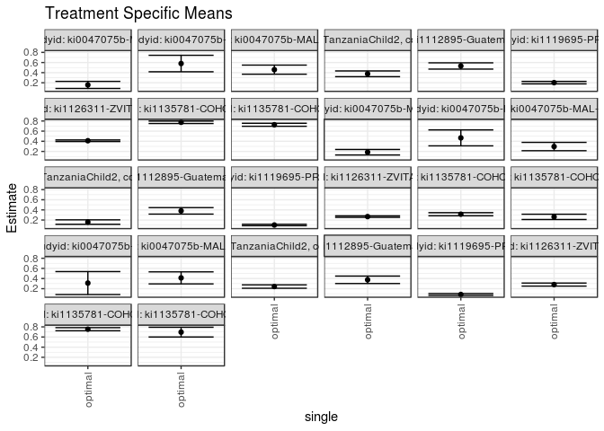

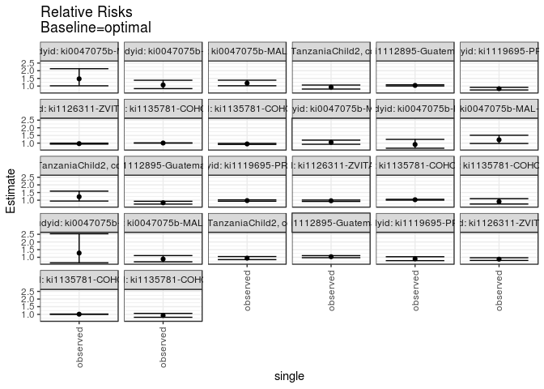

## Results Table

### Parameter: TSM

| agecat | studyid | country | intervention_level | baseline_level | estimate | ci_lower | ci_upper |
| --- | --- | --- | --- | --- | --- | --- | --- |
| 0-24 months | ki0047075b-MAL-ED | BRAZIL | optimal | NA | 0.1575521 | 0.0875480 | 0.2275562 |
| 0-24 months | ki0047075b-MAL-ED | PERU | optimal | NA | 0.5796675 | 0.4171432 | 0.7421919 |
| 0-24 months | ki0047075b-MAL-ED | SOUTH AFRICA | optimal | NA | 0.4590590 | 0.3693268 | 0.5487912 |
| 0-24 months | ki1066203-TanzaniaChild2 | TANZANIA, UNITED REPUBLIC OF | optimal | NA | 0.3769277 | 0.3203041 | 0.4335512 |
| 0-24 months | ki1112895-Guatemala BSC | GUATEMALA | optimal | NA | 0.5316373 | 0.4698622 | 0.5934125 |
| 0-24 months | ki1119695-PROBIT | BELARUS | optimal | NA | 0.2027442 | 0.1785130 | 0.2269754 |
| 0-24 months | ki1126311-ZVITAMBO | ZIMBABWE | optimal | NA | 0.4106730 | 0.3954484 | 0.4258976 |
| 0-24 months | ki1135781-COHORTS | GUATEMALA | optimal | NA | 0.7746287 | 0.7499949 | 0.7992625 |
| 0-24 months | ki1135781-COHORTS | PHILIPPINES | optimal | NA | 0.7257131 | 0.6959132 | 0.7555129 |
| 0-6 months | ki0047075b-MAL-ED | BRAZIL | optimal | NA | 0.1839864 | 0.1296603 | 0.2383125 |
| 0-6 months | ki0047075b-MAL-ED | PERU | optimal | NA | 0.4671450 | 0.3097539 | 0.6245362 |
| 0-6 months | ki0047075b-MAL-ED | SOUTH AFRICA | optimal | NA | 0.2958761 | 0.2139726 | 0.3777797 |
| 0-6 months | ki1066203-TanzaniaChild2 | TANZANIA, UNITED REPUBLIC OF | optimal | NA | 0.1597476 | 0.1158263 | 0.2036688 |
| 0-6 months | ki1112895-Guatemala BSC | GUATEMALA | optimal | NA | 0.3810142 | 0.3171211 | 0.4449074 |
| 0-6 months | ki1119695-PROBIT | BELARUS | optimal | NA | 0.1020644 | 0.0879864 | 0.1161423 |
| 0-6 months | ki1126311-ZVITAMBO | ZIMBABWE | optimal | NA | 0.2679227 | 0.2529611 | 0.2828843 |
| 0-6 months | ki1135781-COHORTS | GUATEMALA | optimal | NA | 0.3147899 | 0.2845341 | 0.3450458 |
| 0-6 months | ki1135781-COHORTS | PHILIPPINES | optimal | NA | 0.2623947 | 0.2101779 | 0.3146114 |
| 6-24 months | ki0047075b-MAL-ED | PERU | optimal | NA | 0.3104470 | 0.0840207 | 0.5368733 |
| 6-24 months | ki0047075b-MAL-ED | SOUTH AFRICA | optimal | NA | 0.4127128 | 0.2939253 | 0.5315004 |
| 6-24 months | ki1066203-TanzaniaChild2 | TANZANIA, UNITED REPUBLIC OF | optimal | NA | 0.2419376 | 0.2083105 | 0.2755646 |
| 6-24 months | ki1112895-Guatemala BSC | GUATEMALA | optimal | NA | 0.3750723 | 0.3015810 | 0.4485635 |
| 6-24 months | ki1119695-PROBIT | BELARUS | optimal | NA | 0.0855520 | 0.0674044 | 0.1036996 |
| 6-24 months | ki1126311-ZVITAMBO | ZIMBABWE | optimal | NA | 0.2804745 | 0.2503043 | 0.3106448 |
| 6-24 months | ki1135781-COHORTS | GUATEMALA | optimal | NA | 0.7545286 | 0.7238680 | 0.7851892 |
| 6-24 months | ki1135781-COHORTS | PHILIPPINES | optimal | NA | 0.6964290 | 0.6001025 | 0.7927555 |

### Parameter: E(Y)

| agecat | studyid | country | intervention_level | baseline_level | estimate | ci_lower | ci_upper |
| --- | --- | --- | --- | --- | --- | --- | --- |
| 0-24 months | ki0047075b-MAL-ED | BRAZIL | observed | NA | 0.2317597 | 0.1774632 | 0.2860561 |
| 0-24 months | ki0047075b-MAL-ED | PERU | observed | NA | 0.6204620 | 0.5657315 | 0.6751926 |
| 0-24 months | ki0047075b-MAL-ED | SOUTH AFRICA | observed | NA | 0.5445860 | 0.4894148 | 0.5997572 |
| 0-24 months | ki1066203-TanzaniaChild2 | TANZANIA, UNITED REPUBLIC OF | observed | NA | 0.3482105 | 0.3290467 | 0.3673744 |
| 0-24 months | ki1112895-Guatemala BSC | GUATEMALA | observed | NA | 0.5531915 | 0.4950624 | 0.6113206 |
| 0-24 months | ki1119695-PROBIT | BELARUS | observed | NA | 0.1674854 | 0.1488048 | 0.1861659 |
| 0-24 months | ki1126311-ZVITAMBO | ZIMBABWE | observed | NA | 0.3967178 | 0.3886181 | 0.4048175 |
| 0-24 months | ki1135781-COHORTS | GUATEMALA | observed | NA | 0.7796189 | 0.7562250 | 0.8030128 |
| 0-24 months | ki1135781-COHORTS | PHILIPPINES | observed | NA | 0.6868787 | 0.6703303 | 0.7034272 |
| 0-6 months | ki0047075b-MAL-ED | BRAZIL | observed | NA | 0.1931330 | 0.1423366 | 0.2439295 |
| 0-6 months | ki0047075b-MAL-ED | PERU | observed | NA | 0.4257426 | 0.3699763 | 0.4815088 |
| 0-6 months | ki0047075b-MAL-ED | SOUTH AFRICA | observed | NA | 0.3598726 | 0.3067005 | 0.4130447 |
| 0-6 months | ki1066203-TanzaniaChild2 | TANZANIA, UNITED REPUBLIC OF | observed | NA | 0.1957895 | 0.1798275 | 0.2117515 |
| 0-6 months | ki1112895-Guatemala BSC | GUATEMALA | observed | NA | 0.3169811 | 0.2608532 | 0.3731091 |
| 0-6 months | ki1119695-PROBIT | BELARUS | observed | NA | 0.0995087 | 0.0864641 | 0.1125533 |
| 0-6 months | ki1126311-ZVITAMBO | ZIMBABWE | observed | NA | 0.2581291 | 0.2508782 | 0.2653799 |
| 0-6 months | ki1135781-COHORTS | GUATEMALA | observed | NA | 0.3244353 | 0.2950189 | 0.3538517 |
| 0-6 months | ki1135781-COHORTS | PHILIPPINES | observed | NA | 0.2385686 | 0.2233602 | 0.2537770 |
| 6-24 months | ki0047075b-MAL-ED | PERU | observed | NA | 0.3959732 | 0.3171819 | 0.4747644 |
| 6-24 months | ki0047075b-MAL-ED | SOUTH AFRICA | observed | NA | 0.3647799 | 0.2897219 | 0.4398379 |
| 6-24 months | ki1066203-TanzaniaChild2 | TANZANIA, UNITED REPUBLIC OF | observed | NA | 0.2278162 | 0.2071874 | 0.2484451 |
| 6-24 months | ki1112895-Guatemala BSC | GUATEMALA | observed | NA | 0.3891892 | 0.3187405 | 0.4596379 |
| 6-24 months | ki1119695-PROBIT | BELARUS | observed | NA | 0.0768510 | 0.0628857 | 0.0908164 |
| 6-24 months | ki1126311-ZVITAMBO | ZIMBABWE | observed | NA | 0.2458975 | 0.2364144 | 0.2553806 |
| 6-24 months | ki1135781-COHORTS | GUATEMALA | observed | NA | 0.7621951 | 0.7330377 | 0.7913526 |
| 6-24 months | ki1135781-COHORTS | PHILIPPINES | observed | NA | 0.6452074 | 0.6247246 | 0.6656902 |

### Parameter: RR

| agecat | studyid | country | intervention_level | baseline_level | estimate | ci_lower | ci_upper |
| --- | --- | --- | --- | --- | --- | --- | --- |
| 0-24 months | ki0047075b-MAL-ED | BRAZIL | observed | optimal | 1.4710031 | 1.0148745 | 2.1321355 |
| 0-24 months | ki0047075b-MAL-ED | PERU | observed | optimal | 1.0703757 | 0.8309038 | 1.3788649 |
| 0-24 months | ki0047075b-MAL-ED | SOUTH AFRICA | observed | optimal | 1.1863094 | 1.0184827 | 1.3817908 |
| 0-24 months | ki1066203-TanzaniaChild2 | TANZANIA, UNITED REPUBLIC OF | observed | optimal | 0.9238126 | 0.8029109 | 1.0629196 |
| 0-24 months | ki1112895-Guatemala BSC | GUATEMALA | observed | optimal | 1.0405430 | 1.0027206 | 1.0797920 |
| 0-24 months | ki1119695-PROBIT | BELARUS | observed | optimal | 0.8260920 | 0.7425034 | 0.9190908 |
| 0-24 months | ki1126311-ZVITAMBO | ZIMBABWE | observed | optimal | 0.9660188 | 0.9364787 | 0.9964907 |
| 0-24 months | ki1135781-COHORTS | GUATEMALA | observed | optimal | 1.0064421 | 0.9980209 | 1.0149343 |
| 0-24 months | ki1135781-COHORTS | PHILIPPINES | observed | optimal | 0.9464880 | 0.9124126 | 0.9818360 |
| 0-6 months | ki0047075b-MAL-ED | BRAZIL | observed | optimal | 1.0497137 | 0.9229275 | 1.1939171 |
| 0-6 months | ki0047075b-MAL-ED | PERU | observed | optimal | 0.9113713 | 0.6666559 | 1.2459165 |
| 0-6 months | ki0047075b-MAL-ED | SOUTH AFRICA | observed | optimal | 1.2162948 | 0.9778098 | 1.5129456 |
| 0-6 months | ki1066203-TanzaniaChild2 | TANZANIA, UNITED REPUBLIC OF | observed | optimal | 1.2256179 | 0.9444044 | 1.5905679 |
| 0-6 months | ki1112895-Guatemala BSC | GUATEMALA | observed | optimal | 0.8319405 | 0.7461177 | 0.9276351 |
| 0-6 months | ki1119695-PROBIT | BELARUS | observed | optimal | 0.9749601 | 0.9316516 | 1.0202819 |
| 0-6 months | ki1126311-ZVITAMBO | ZIMBABWE | observed | optimal | 0.9634460 | 0.9179464 | 1.0112009 |
| 0-6 months | ki1135781-COHORTS | GUATEMALA | observed | optimal | 1.0306407 | 1.0024605 | 1.0596131 |
| 0-6 months | ki1135781-COHORTS | PHILIPPINES | observed | optimal | 0.9091975 | 0.7510570 | 1.1006357 |
| 6-24 months | ki0047075b-MAL-ED | PERU | observed | optimal | 1.2754936 | 0.6408651 | 2.5385750 |
| 6-24 months | ki0047075b-MAL-ED | SOUTH AFRICA | observed | optimal | 0.8838588 | 0.7028210 | 1.1115295 |
| 6-24 months | ki1066203-TanzaniaChild2 | TANZANIA, UNITED REPUBLIC OF | observed | optimal | 0.9416323 | 0.8464478 | 1.0475204 |
| 6-24 months | ki1112895-Guatemala BSC | GUATEMALA | observed | optimal | 1.0376379 | 0.9733908 | 1.1061255 |
| 6-24 months | ki1119695-PROBIT | BELARUS | observed | optimal | 0.8982965 | 0.7801200 | 1.0343750 |
| 6-24 months | ki1126311-ZVITAMBO | ZIMBABWE | observed | optimal | 0.8767195 | 0.7924423 | 0.9699597 |
| 6-24 months | ki1135781-COHORTS | GUATEMALA | observed | optimal | 1.0101607 | 1.0004262 | 1.0199899 |
| 6-24 months | ki1135781-COHORTS | PHILIPPINES | observed | optimal | 0.9264511 | 0.8081028 | 1.0621318 |

### Parameter: PAR

| agecat | studyid | country | intervention_level | baseline_level | estimate | ci_lower | ci_upper |
| --- | --- | --- | --- | --- | --- | --- | --- |
| 0-24 months | ki0047075b-MAL-ED | BRAZIL | optimal | NA | 0.0742075 | 0.0136559 | 0.1347591 |
| 0-24 months | ki0047075b-MAL-ED | PERU | optimal | NA | 0.0407945 | -0.1055110 | 0.1871000 |
| 0-24 months | ki0047075b-MAL-ED | SOUTH AFRICA | optimal | NA | 0.0855270 | 0.0162852 | 0.1547688 |
| 0-24 months | ki1066203-TanzaniaChild2 | TANZANIA, UNITED REPUBLIC OF | optimal | NA | -0.0287171 | -0.0815968 | 0.0241625 |
| 0-24 months | ki1112895-Guatemala BSC | GUATEMALA | optimal | NA | 0.0215542 | 0.0020575 | 0.0410508 |
| 0-24 months | ki1119695-PROBIT | BELARUS | optimal | NA | -0.0352588 | -0.0556325 | -0.0148852 |
| 0-24 months | ki1126311-ZVITAMBO | ZIMBABWE | optimal | NA | -0.0139552 | -0.0267108 | -0.0011995 |
| 0-24 months | ki1135781-COHORTS | GUATEMALA | optimal | NA | 0.0049902 | -0.0015083 | 0.0114887 |
| 0-24 months | ki1135781-COHORTS | PHILIPPINES | optimal | NA | -0.0388343 | -0.0653332 | -0.0123355 |
| 0-6 months | ki0047075b-MAL-ED | BRAZIL | optimal | NA | 0.0091466 | -0.0146074 | 0.0329007 |
| 0-6 months | ki0047075b-MAL-ED | PERU | optimal | NA | -0.0414025 | -0.1874752 | 0.1046702 |
| 0-6 months | ki0047075b-MAL-ED | SOUTH AFRICA | optimal | NA | 0.0639965 | -0.0002192 | 0.1282122 |
| 0-6 months | ki1066203-TanzaniaChild2 | TANZANIA, UNITED REPUBLIC OF | optimal | NA | 0.0360419 | -0.0056295 | 0.0777133 |
| 0-6 months | ki1112895-Guatemala BSC | GUATEMALA | optimal | NA | -0.0640331 | -0.1025217 | -0.0255445 |
| 0-6 months | ki1119695-PROBIT | BELARUS | optimal | NA | -0.0025557 | -0.0071990 | 0.0020877 |
| 0-6 months | ki1126311-ZVITAMBO | ZIMBABWE | optimal | NA | -0.0097937 | -0.0227569 | 0.0031696 |
| 0-6 months | ki1135781-COHORTS | GUATEMALA | optimal | NA | 0.0096454 | 0.0009178 | 0.0183730 |
| 0-6 months | ki1135781-COHORTS | PHILIPPINES | optimal | NA | -0.0238261 | -0.0739269 | 0.0262747 |
| 6-24 months | ki0047075b-MAL-ED | PERU | optimal | NA | 0.0855262 | -0.1276634 | 0.2987158 |
| 6-24 months | ki0047075b-MAL-ED | SOUTH AFRICA | optimal | NA | -0.0479330 | -0.1417782 | 0.0459123 |
| 6-24 months | ki1066203-TanzaniaChild2 | TANZANIA, UNITED REPUBLIC OF | optimal | NA | -0.0141213 | -0.0399197 | 0.0116770 |
| 6-24 months | ki1112895-Guatemala BSC | GUATEMALA | optimal | NA | 0.0141169 | -0.0098224 | 0.0380563 |
| 6-24 months | ki1119695-PROBIT | BELARUS | optimal | NA | -0.0087009 | -0.0206267 | 0.0032248 |
| 6-24 months | ki1126311-ZVITAMBO | ZIMBABWE | optimal | NA | -0.0345770 | -0.0629329 | -0.0062212 |
| 6-24 months | ki1135781-COHORTS | GUATEMALA | optimal | NA | 0.0076665 | 0.0003916 | 0.0149414 |
| 6-24 months | ki1135781-COHORTS | PHILIPPINES | optimal | NA | -0.0512216 | -0.1463136 | 0.0438705 |

### Parameter: PAF

| agecat | studyid | country | intervention_level | baseline_level | estimate | ci_lower | ci_upper |
| --- | --- | --- | --- | --- | --- | --- | --- |
| 0-24 months | ki0047075b-MAL-ED | BRAZIL | optimal | NA | 0.3201918 | 0.0146565 | 0.5309867 |
| 0-24 months | ki0047075b-MAL-ED | PERU | optimal | NA | 0.0657486 | -0.2035088 | 0.2747658 |
| 0-24 months | ki0047075b-MAL-ED | SOUTH AFRICA | optimal | NA | 0.1570496 | 0.0181473 | 0.2763014 |
| 0-24 months | ki1066203-TanzaniaChild2 | TANZANIA, UNITED REPUBLIC OF | optimal | NA | -0.0824706 | -0.2454682 | 0.0591951 |
| 0-24 months | ki1112895-Guatemala BSC | GUATEMALA | optimal | NA | 0.0389633 | 0.0027132 | 0.0738957 |
| 0-24 months | ki1119695-PROBIT | BELARUS | optimal | NA | -0.2105189 | -0.3467952 | -0.0880318 |
| 0-24 months | ki1126311-ZVITAMBO | ZIMBABWE | optimal | NA | -0.0351766 | -0.0678299 | -0.0035217 |
| 0-24 months | ki1135781-COHORTS | GUATEMALA | optimal | NA | 0.0064008 | -0.0019830 | 0.0147145 |
| 0-24 months | ki1135781-COHORTS | PHILIPPINES | optimal | NA | -0.0565374 | -0.0959954 | -0.0185000 |
| 0-6 months | ki0047075b-MAL-ED | BRAZIL | optimal | NA | 0.0473593 | -0.0835087 | 0.1624209 |
| 0-6 months | ki0047075b-MAL-ED | PERU | optimal | NA | -0.0972477 | -0.5000243 | 0.1973780 |
| 0-6 months | ki0047075b-MAL-ED | SOUTH AFRICA | optimal | NA | 0.1778309 | -0.0226938 | 0.3390377 |
| 0-6 months | ki1066203-TanzaniaChild2 | TANZANIA, UNITED REPUBLIC OF | optimal | NA | 0.1840851 | -0.0588684 | 0.3712937 |
| 0-6 months | ki1112895-Guatemala BSC | GUATEMALA | optimal | NA | -0.2020091 | -0.3402712 | -0.0780101 |
| 0-6 months | ki1119695-PROBIT | BELARUS | optimal | NA | -0.0256830 | -0.0733626 | 0.0198787 |
| 0-6 months | ki1126311-ZVITAMBO | ZIMBABWE | optimal | NA | -0.0379409 | -0.0893882 | 0.0110768 |
| 0-6 months | ki1135781-COHORTS | GUATEMALA | optimal | NA | 0.0297298 | 0.0024545 | 0.0562593 |
| 0-6 months | ki1135781-COHORTS | PHILIPPINES | optimal | NA | -0.0998710 | -0.3314569 | 0.0914342 |
| 6-24 months | ki0047075b-MAL-ED | PERU | optimal | NA | 0.2159898 | -0.5603909 | 0.6060782 |
| 6-24 months | ki0047075b-MAL-ED | SOUTH AFRICA | optimal | NA | -0.1314025 | -0.4228373 | 0.1003388 |
| 6-24 months | ki1066203-TanzaniaChild2 | TANZANIA, UNITED REPUBLIC OF | optimal | NA | -0.0619857 | -0.1814077 | 0.0453647 |
| 6-24 months | ki1112895-Guatemala BSC | GUATEMALA | optimal | NA | 0.0362727 | -0.0273366 | 0.0959435 |
| 6-24 months | ki1119695-PROBIT | BELARUS | optimal | NA | -0.1132182 | -0.2818541 | 0.0332327 |
| 6-24 months | ki1126311-ZVITAMBO | ZIMBABWE | optimal | NA | -0.1406157 | -0.2619216 | -0.0309706 |
| 6-24 months | ki1135781-COHORTS | GUATEMALA | optimal | NA | 0.0100585 | 0.0004260 | 0.0195981 |
| 6-24 months | ki1135781-COHORTS | PHILIPPINES | optimal | NA | -0.0793878 | -0.2374664 | 0.0584973 |